# Linear Algebra for Data Science, Part 1

PSTAT 134 (Winter 2026)

Author

Affiliation

Sang-Yun Oh

University of California, Santa Barbara

## Linear Algebra for Data Science

- Data often come in tabular form
- Linear algebra provides tools to manipulate and analyze such data efficiently
- Many data analysis and solutions can be expressed using linear algebra
- Software libraries (e.g., NumPy, R, MATLAB) optimize matrix operations for performance
  - [NVIDIA CUDA](https://developer.nvidia.com/cublas) has cuBLAS for GPU-accelerated linear algebra
  - [Intel MKL](https://www.intel.com/content/www/us/en/developer/tools/oneapi/onemkl.html) optimizes linear algebra on Intel CPUs
  - [Google XLA](https://cloud.google.com/blog/products/compute/inside-the-ironwood-tpu-codesigned-ai-stack) for optimizing linear algebra computations in TensorFlow
- Understanding linear algebra is essential for effective data science

## Single Factor Representation of Data

- Recall the IQ model for student test scores: i.e., $\hat x_i = q_i v,$
  $$\mathbf{x}_{i \cdot}=\begin{pmatrix}x_{i 1}& x_{i 2} & \dots & x_{i 5}\end{pmatrix},\ \mathbf{v} = \begin{pmatrix} v_1 & v_2 & \cdots & v_5 \end{pmatrix}'$$
  where student $i$’s test scores $\mathbf{x}_{i \cdot}$ is $\mathbf{v}$ scaled by $q_i$.
- Matrix form: for $n$ students, $\mathbf{q} = \begin{pmatrix} q_1 & \cdots & q_n \end{pmatrix}'$.
  $$\mathbf{X} \stackrel{?}{=} \mathbf{q}\mathbf{v}^\top =
  \begin{pmatrix} q_1 \\ \vdots \\ q_n \end{pmatrix} \begin{pmatrix} v_1 & \cdots & v_5
  \end{pmatrix}$$
- If $\mathbf{X} \approx \mathbf{q}\mathbf{v}^\top$, then single factor model is approximately correct.[^1]

## Rank-$k$ Approximation of Test Scores Data

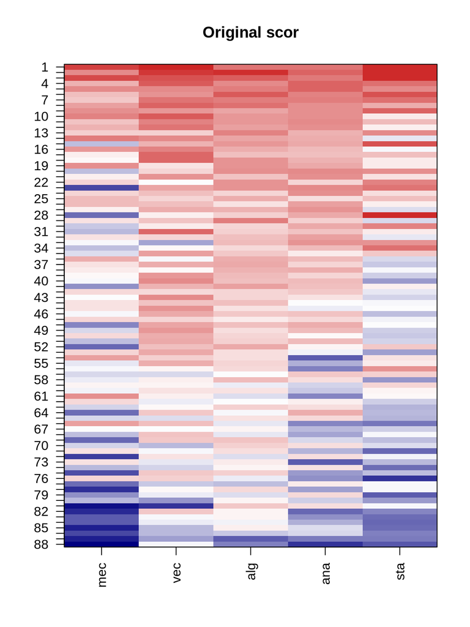

Original

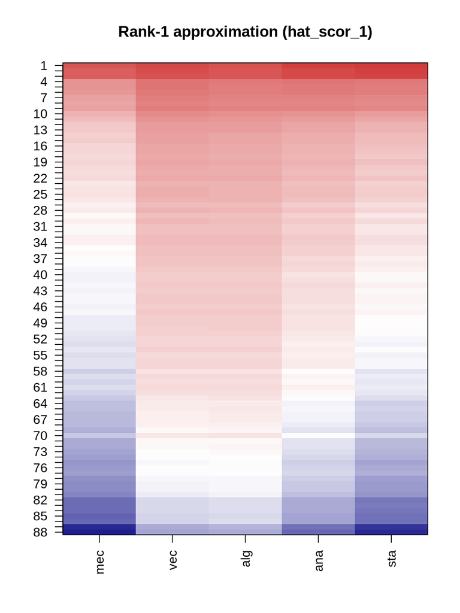

Rank-1 Approximation

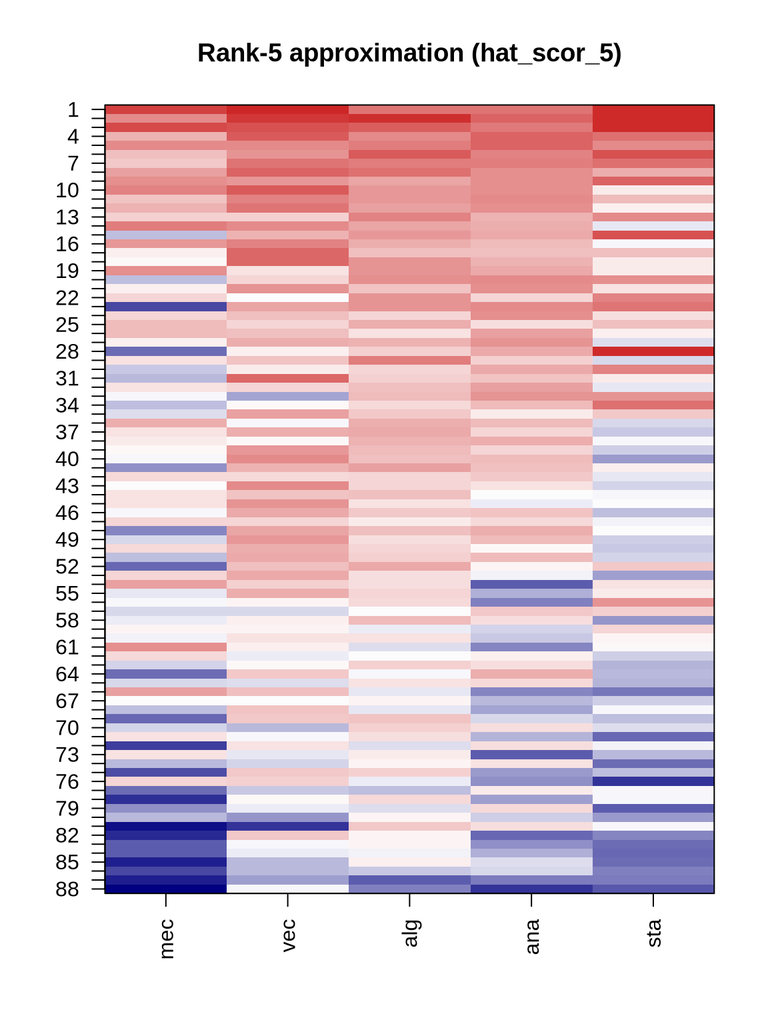

Rank-5 Approximation (exact)

```r
library(bootstrap)
data(scor)

pc <- prcomp(scor, scale = FALSE, center = TRUE)  # PCA

pc_approx_scor <- function(pc, num_pcs = 1) {
  Q = pc$x[,1:num_pcs, drop=FALSE]        # first PC scores
  V = pc$rotation[,1:num_pcs, drop=FALSE] # first PC loadings
  mu = pc$center              # variable means

  scor_hat = Q %*% t(V)
  scor_hat = sweep(scor_hat, 2, mu, "+")

  return(scor_hat)
}

hat_scor_1 = pc_approx_scor(pc, num_pcs = 1)
hat_scor_5 = pc_approx_scor(pc, num_pcs = 5)

# heatmaps: original scor vs rank-1 approximation
cols <- colorRampPalette(c("navy", "white", "firebrick3"))(100)
zmin <- min(c(as.matrix(scor), as.matrix(hat_scor_1), as.matrix(hat_scor_5)))
zmax <- max(c(as.matrix(scor), as.matrix(hat_scor_1), as.matrix(hat_scor_5)))

plot_heat <- function(mat, main = "") {
  m <- as.matrix(mat)
  image(1:ncol(m), 1:nrow(m), t(apply(m, 2, rev)),
        col = cols, axes = FALSE, xlab = "", ylab = "",
        main = main, zlim = c(zmin, zmax))
  axis(1, at = 1:ncol(m), labels = colnames(m), las = 2)
  axis(2, at = 1:nrow(m), labels = rev(rownames(m)), las = 2)
  box()
}

plot_heat(scor, "Original scor")
plot_heat(hat_scor_1, "Rank-1 approximation (hat_scor_1)")
plot_heat(hat_scor_5, "Rank-5 approximation (hat_scor_5)")
```

## Matrix Factorization as Representation Learning

- If data matrix $X$ has $n$ samples and $p$ features,
- PCA: $X = Q_V V^\top$, where $V$ has orthonormal columns
- ICA: $X = Q_W W^\top$, where $W$ has “independent” columns
- NMF: $X = Q_Y Y^\top$, where $Q_Y$ and $Y$ are non-negative matrices
- Bases, $V$, $W$, and $Y$, are calculated by imposing different characteristics.
- Each can be viewed as representation learning method.
- Choice of method depends on data characteristics and analysis goals
- Sometimes observations are columns and variables are rows

## Representation Learning in Data Science

- PCA rotates the data to compute transformed features
- Other non-linear methods: t-SNE and UMAP
- Similar goals: find lower-dimensional subspace representation of high-dimensional data
- Start with a suitable representation (basis vectors) for the data

. . .

- Linear algebra is fundamental for understanding and implementing these techniques
- Bases, dimensions, subspaces, etc., are key concepts/terminology in linear algebra
- Motivates review of linear algebra for data science applications

## Linear Algebra Definitions

**Definition: Subspace**

A subspace of $\mathbb{R}^n$ is a nonempty subset $\varnothing \neq V \subseteq \mathbb{R}^n$ that satisfies

1. for every $\mathbf{v}, \mathbf{w} \in V$, the sum $\mathbf{v}+\mathbf{w} \in V$, and
2. for every $\mathbf{v} \in V$ and every $c \in \mathbb{R}$, the scalar product $c \mathbf{v} \in V$.

. . .

**Definition 1.4: Linear Combination**

Let $\mathbf{v}_1, \ldots, \mathbf{v}_k \in \mathbb{R}^n$. A sum of the form

$$c_1 \mathbf{v}_1+c_2 \mathbf{v}_2+\cdots+c_k \mathbf{v}_k=\sum_{i=1}^k c_i \mathbf{v}_i,$$

where the coefficients $c_1, c_2, \ldots, c_k \in \mathbb{R}$ are any scalars, is known as a *linear combination* of the vectors $\mathbf{v}_1, \ldots, \mathbf{v}_k$.

. . .

**Definition 1.5: Span of Vectors**

The span of a finite collection of vectors $\mathbf{v}_1, \ldots, \mathbf{v}_k \in \mathbb{R}^n$ is the subset $V=\operatorname{span}\left\{\mathbf{v}_1, \ldots, \mathbf{v}_k\right\} \subset \mathbb{R}^n$ consisting of all possible linear combinations for $c_1, \ldots, c_k \in \mathbb{R}$.

## Linear Algebra Definitions (contd.)

**Proposition 1.6: Span is a Subspace**

The span of any collection of vectors in $\mathbb{R}^n$ is a subspace.

. . .

**Definition 1.9: Linear Dependence and Independence**

The vectors $\mathbf{v}_1, \ldots, \mathbf{v}_k \in \mathbb{R}^n$ are called *linearly dependent* if there exist scalars $c_1, \ldots, c_k \in \mathbb{R}$, not all zero, such that

$$c_1 \mathbf{v}_1+\cdots+c_k \mathbf{v}_k=\mathbf{0} .$$

Vectors that are not linearly dependent are called *linearly independent*.

. . .

**Lemma 1.11: Extending a Linear Independent Set**

Let $\mathbf{v}_1, \ldots, \mathbf{v}_k$ be linearly independent. If $\mathbf{v}_{k+1} \notin \operatorname{span}\left\{\mathbf{v}_1, \ldots, \mathbf{v}_k\right\}$, then $\mathbf{v}_1, \ldots, \mathbf{v}_{k+1}$ are also linearly independent.

. . .

**Definition 1.12: Basis Vectors**

A basis of a subspace $V \subseteq \mathbb{R}^n$ is a finite set of vectors $\mathbf{v}_1, \ldots, \mathbf{v}_k \in V$ that (a) spans $V$, and (b) is linearly independent.

## Application to Data Science

- Suppose data in some subspace $V$, and
- A suitable basis $\mathbf{v}_1, \ldots, \mathbf{v}_k$ exist for the data in $V$.
- Then the basis vectors span subspace $V$
- Basis vectors provide a coordinate system for the subspace
- Data can be represented in terms of basis vectors
- Each data point is expressed as a linear combination of basis vectors
- Linear combination coefficients represent the data points
- Note: basis vectors are linearly independent but *need not be orthogonal*

## Examples of Basis Vectors for Representing Data

- Wavelet basis in signal processing
- Fourier basis in frequency analysis
- Polynomial basis in regression analysis
- Principal component basis in PCA
- Independent component basis in ICA
- Non-negative basis in NMF
- Each basis has unique properties suited for specific applications

. . .

Why do these basis vectors matter? How do we choose one set of basis vectors over another? What common characteristics do they share? What are the differences among them?

## Dimension and Rank

**Theorem 1.14: Dimension of a Subspace**

Suppose the subspace $V \subset \mathbb{R}^n$ has a basis $\mathbf{v}_1, \ldots, \mathbf{v}_k \in V$. **Then every other basis of $V$ has the same number, $k$, of vectors in it.** This number is called the *dimension* of $V$, and written $\operatorname{dim} V=k$. In particular, $0<k \leq n$.

. . .

**Lemma 1.17: Number of Vectors in a Spanning Set**

Suppose $\mathbf{v}_1, \ldots, \mathbf{v}_k$ span a subspace $V \subset \mathbb{R}^n$. Then every set of $m>k$ vectors $\mathbf{w}_1, \ldots, \mathbf{w}_m \in V$ is linearly dependent.

. . .

**Proposition 1.18: Rank**

The vectors $\mathbf{v}_1, \ldots, \mathbf{v}_k$ form a basis of a subspace $V \subset \mathbb{R}^n$ if and only if every $\mathbf{x} \in V$ can be written uniquely as a linear combination of the basis vectors:
$$\mathbf{x}=c_1 \mathbf{v}_1+\cdots+c_k \mathbf{v}_k=\sum_{i=1}^k c_i \mathbf{v}_i .$$

## Gaining Intuition about Dimension and Rank

Suppose my data exist in some subspace V. Explain to me the relevance of the following result: e.g., Lemma 1.17.

- If you collect 100 observations ($m=100$) but they all live in a 3-dimensional subspace ($k=3$), this theorem guarantees that at least 97 of those observations are “summarizable” by the others.
- You don’t have 100 unique pieces of information; you have 3 pieces of information repeated and combined in 100 different ways.
- This is the theoretical basis for Dimensionality Reduction. If you know your data is confined to a small $k$, you can safely “compress” your $m$ vectors down to $k$ without losing any structural information.

. . .

*Exercise: use an LLM to understand the implication of Theorem 1.14 in context of different basis vectors.*

**Theorem 1.19: Summary of Results for $\mathbb{R}^n$**

1. Every set of more than $n$ vectors in $\mathbb{R}^n$ is linearly dependent.
2. No set of fewer than $n$ vectors spans $\mathbb{R}^n$.
3. A set of $n$ vectors forms a basis if and only if it spans $\mathbb{R}^n$.
4. A set of $n$ vectors forms a basis if and only if it is linearly independent.

. . .

**Proposition 1.21: Dimension of Subspaces**

If $W \subseteq V \subseteq \mathbb{R}^n$ are subspaces, then $0 \leq \operatorname{dim} W \leq \operatorname{dim} V \leq n$. Moreover, $\operatorname{dim} V=\operatorname{dim} W$ if and only if $V=W$.

. . .

References:

- Calder and Olver (2025) ([ebook link at UCSB library](https://search.library.ucsb.edu/permalink/01UCSB_INST/1aqck9j/alma9923611859406531))
- Bapat (2000) ([ebook link at UCSB library](https://search.library.ucsb.edu/permalink/01UCSB_INST/1876c7q/cdi_askewsholts_vlebooks_9781447127390))

## Applying Linear Algebra to Representing Data

- Data matrices can be viewed as collections of vectors in high-dimensional space
- Test scores data: each student’s scores form a vector in $\mathbb{R}^5$
- Linear combinations of basis vectors can represent data points
- PCA components serve as orthogonal basis vectors
- 5 components span the entire space $\mathbb{R}^5$
- All rows can be expressed as linear combinations of 5 basis vectors (exact representation when using all 5 components)

**Definition: Image of a Matrix**

Let $A=\left(\mathbf{v}_1 \ldots \mathbf{v}_n\right)$ be an $m \times n$ matrix, whose columns $\mathbf{v}_1, \ldots, \mathbf{v}_n$ form a set of $n$ vectors in $\mathbb{R}^m$. The subspace spanned by its column vectors is known as the image of $A$, and denoted
$$\operatorname{img} A=\operatorname{span}\left\{\mathbf{v}_1, \ldots, \mathbf{v}_n\right\} \subset \mathbb{R}^m .$$

Alternative names appearing in the literature include column space and range. Equivalently, the image of $A$ can be defined as

$$\operatorname{img} A=\left\{A \mathbf{x} \mid \mathbf{x} \in \mathbb{R}^n\right\} \subset \mathbb{R}^m .$$

We conclude that a vector $\mathbf{b}$ lies in the image of $A$ if and only if the linear system $A \mathbf{x}=\mathbf{b}$ has a solution.

. . .

**Definition: Kernel of a Matrix**

The kernel or, alternatively, null space of $A$ is denoted by

$$\operatorname{ker} A=\left\{\mathbf{z} \in \mathbb{R}^n \mid A \mathbf{z}=\mathbf{0}\right\} \subset \mathbb{R}^n .$$

The kernel is the set of solutions $\mathbf{z}$ to the homogeneous linear system $A \mathbf{z}=\mathbf{0}$.

**Definition 3.6: Rank of a Matrix**

The rank of a matrix $A$ is the dimension of its image:

$$\operatorname{rank} A=\operatorname{dim}\operatorname{img} A .$$

**Definition 3.8: Nullity of a Matrix**

The nullity of a matrix $A$ is the dimension of its kernel:

$$\operatorname{ nullity } A=\operatorname{dim} \operatorname{ker} A \text {. }$$

**Theorem 3.9: Rank and Nullity of a Matrix**

Let $A$ be an $m \times n$ matrix. Then

$$\operatorname{rank} A+\text { nullity } A=n .$$

## Rank Factorization of Matrices

**Example: Matrix as a Sum of Rank-One Matrices**

An $m \times n$ matrix $A$ has $\operatorname{rank} A=1$ if and only if there are nonzero vectors $\mathbf{0} \neq \mathbf{v} \in \mathbb{R}^m, \mathbf{0} \neq \mathbf{w} \in \mathbb{R}^n$, such that $A=\mathbf{v} \mathbf{w}^T$. More generally, we have $\operatorname{rank} A=r>0$ if and only if there exist linearly independent vectors $\mathbf{v}_1, \ldots, \mathbf{v}_r \in \mathbb{R}^m$, $\mathbf{w}_1, \ldots, \mathbf{w}_r \in \mathbb{R}^n$ such that $A$ can be expressed as a sum of $r$ rank one matrices,

$$A=\mathbf{v}_1 \mathbf{w}_1^T+\cdots+\mathbf{v}_r \mathbf{w}_r^T=V W^T,$$

where the matrices $V=\left(\mathbf{v}_1 \ldots \mathbf{v}_r\right) \in \mathcal{M}_{m \times r}, W=\left(\mathbf{w}_1 \ldots \mathbf{w}_r\right) \in \mathcal{M}_{n \times r}$ with the indicated columns both have rank $r$. Moreover, the vectors $\mathbf{v}_1, \ldots, \mathbf{v}_r$ form a basis for $\operatorname{img} A=\operatorname{img} V$.

## PCA as a Rank Factorization of Data Matrix

Suppose test scores $\mathbf{X}$ is represented as a sum of rank-one matrices
$$\mathbf{X}=q_1v_1^\top + \cdots + q_r v_r^\top = \sum_{k=1}^r \mathbf{Q}_k \mathbf{V}_k^T = \mathbf{Q} \mathbf{V}^T$$
where $\mathbf{q}_1, \cdots, \mathbf{q}_r$ are $n$-dimensional vectors and $\mathbf{v}_1, \cdots, \mathbf{v}_r$ are $p$-dimensional vectors for $k=1, \ldots, r$. Rank $r$ has a maximum of $\min(n, p)=5$[^2].

. . .

Is the decomposition into rank one matrices obvious in the way we think about matrix multiplication?

## Matrix Multiplication: Elements of $\boldsymbol{C}$

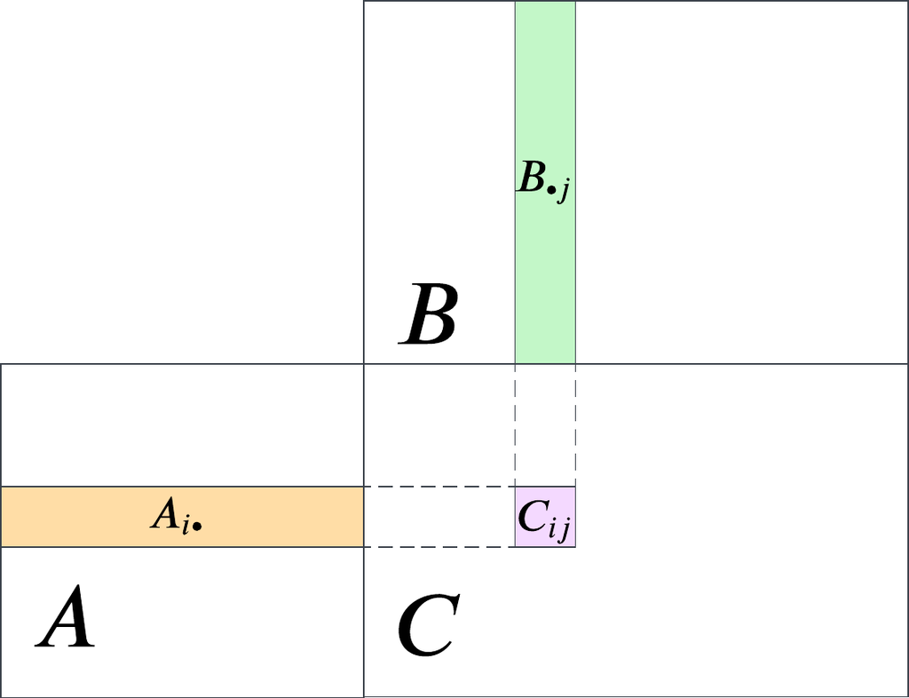

Let $\boldsymbol{C}$ be an $m \times n$ matrix.

The $(i, j)$-th element of the matrix product $\boldsymbol{C}=\boldsymbol{A} \boldsymbol{B}$ is given by
$$C_{i j}=A_{i\bullet} \cdot B_{\bullet j}$$

## Matrix Multiplication: Rows of $\boldsymbol{C}$

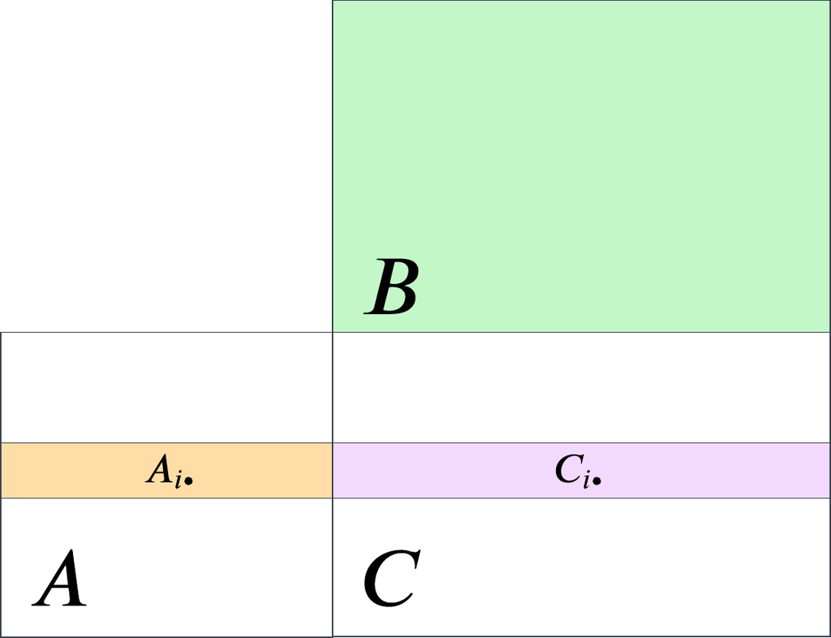

Let $\boldsymbol{C}$ be an $m \times n$ matrix.

The $i$-th row of the matrix product $\boldsymbol{C}=\boldsymbol{A} \boldsymbol{B}$ is given by
$$C_{i \bullet}=A_{i\bullet} \cdot B$$

## Matrix Multiplication: Columns of $\boldsymbol{C}$

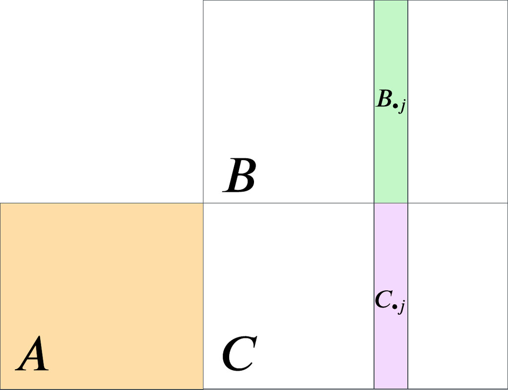

Let $\boldsymbol{C}$ be an $m \times n$ matrix.

The $j$-th column of the matrix product $\boldsymbol{C}=\boldsymbol{A} \boldsymbol{B}$ is given by

$$C_{\bullet j}=A \cdot B_{\bullet j}$$

## Matrix Multiplication: $\boldsymbol{C}=\boldsymbol{A} \boldsymbol{B}$

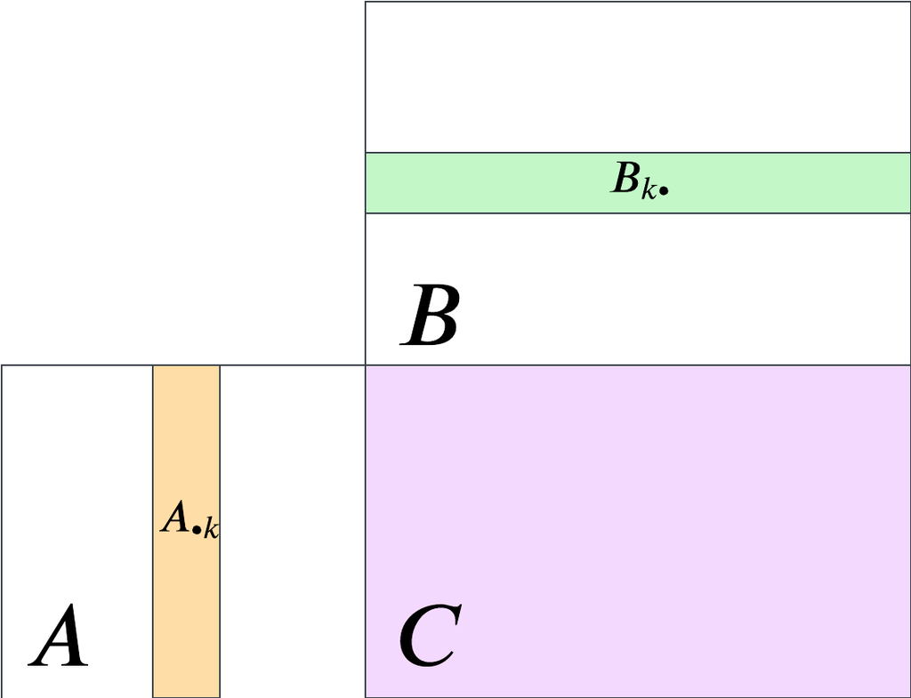

Let $\boldsymbol{C}$ be an $m \times n$ matrix.

The matrix product $\boldsymbol{C}=\boldsymbol{A} \boldsymbol{B}$ is given by
$$C=\sum_{k=1}^K A_{\bullet k} \cdot B_{k \bullet}$$

## References

Bapat, Ravindra. 2000. *Linear Algebra and Linear Models*. Universitext. New York, NY: Springer New York. https://doi.org/10.1007/b97609.

Calder, Jeff, and Peter J. Olver. 2025. *Linear Algebra, Data Science, and Machine Learning*. Springer Undergraduate Texts in Mathematics and Technology. Cham: Springer Nature Switzerland. https://doi.org/10.1007/978-3-031-93764-4.

## Footnotes

[^1]: We decide how close is close enough.
[^2]: We will show later.